# UTA Bus Speeds using GTFS

Chris Day

2022-10-12

```r
library(tidyverse)
library(sf)
library(gtfstools)
library(gtfs2gps)
library(leaflet)
library(hms)
library(geotidy)
library(sfheaders)
library(targets)
source("R/bus_speeds_visuals.R")
source("R/gtfs_functions.R")
```

## Introduction

### Introduction

This Rmarkdown is for extracting bus speeds from GTFS data in order to map it to the travel demand model (TDM) network links. By mapping bus speeds to the link segments in the TDM network, we hope to verify the bus speed ratios currently being used for determining the bus speeds in the TDM. The bus speed ratios represent a ratio of link car travel speed by functional classification and bus type mode.

A previous analysis has already been completed, but the results were inconclusive. That analysis used UTA bus stop point data and didn’t provide any clear evidence on the validity of the speed ratios currently in use. For this reason, we are completed a secondary analysis using a separate dataset.

### Current Ratios

The current ratios being used to determining TDM bus travel speeds are as follows:

| Functional Class | Auto Speed Ratio |
| --- | --- |
| Freeways | 0.95 |
| Freeway Ramps | 0.75 |
| Principal Arterials & Expressways | 0.60 |
| Minor Arterials (Urban) | 0.55 |
| Minor Arterials (Suburban) | 0.65 |
| Collectors | 0.60 |

*minimum bus speed = 10mph

## GTFS Data Analysis

### Input GTFS Data

Below we read in the GTFS data from the 9 September 2019 dataset located at this link: https://transitfeeds.com/p/utah-transportation-authority/59?p=10.

```r
#read in gtfs data
gtfs_path <- "C:/Users/cday/Documents/projects/TDM-Bus-Speeds/data/UTA/gtfs.zip"
uta_gtfs <- gtfstools::read_gtfs(gtfs_path)
```

### Average Speed Calculation

Next we calculate the average speeds based on the daily time schedules and link shape distances. The R package *gtfs2gps* has a built in function to do that for us. After creating a data frame with average speeds we create point and line spatial objects that include speed data.

```r
#calculate average speeds, times, etc.
uta_gps <- tar_read(gtfs_gps)
# Results:
#   356 out of 534 shapes (66.67%) were properly processed.
#   15818 out of 16234 trips (97.44%) were properly processed.

# create point and line datasets
uta_gps_lines <- tar_read(gtfs_gps_lines)
#uta_gps_points <- tar_read(gtfs_gps_points)
```

```r
# merge route name, dir, and other info onto geometry data
uta_gps_lines_arr <- tar_read(triproutes)

#' get timestamp data for each trip and route
#' determine peak and off peak times
uta_gps_lines_atr <- tar_read(timepeaks)
```

Next, we filter by service_id to only include those data points recorded on a weekday (Monday thru Friday).

```r
uta_gps_lines_mf <- tar_read(gps_lines_mf)
```

Finally, a summary table is created where the average, average speeds are taken for the peak and off peak periods, by direction, for each route. The mean distance and mean timepoints are also calculated, in case the average speeds are to be calculated once more.

```r
uta_gps_lines_mf_sum <- tar_read(speed_sums)
head(uta_gps_lines_mf_sum)
```

```
## Simple feature collection with 6 features and 7 fields
## Geometry type: LINESTRING
## Dimension:     XY
## Bounding box:  xmin: -111.9098 ymin: 40.76318 xmax: -111.8882 ymax: 40.76567
## Geodetic CRS:  WGS 84
## # A tibble: 6 × 8
## # Groups:   route_short_name, PkOk, direction_id [1]
##   route_short_name PkOk  direction_id stop_sequence aveTimepoint aveDi…¹ aveSp…²
##   <chr>            <chr>        <int>         <int>        <dbl>     [m]  [km/h]
## 1 11               ok               0             1           88    190.    7.77
## 2 11               ok               0             2          235    961.   14.7
## 3 11               ok               0             3           41    119.   10.4
## 4 11               ok               0             4           58    239.   14.9
## 5 11               ok               0             5           73    244.   12.1
## 6 11               ok               0             6          105    363.   12.5
## # … with 1 more variable: geometry <LINESTRING [°]>, and abbreviated variable
## #   names ¹aveDistance, ²aveSpeed
```

### Verifying Average Speeds

The average speeds are calculated as explained in this link: (https://ipeagit.github.io/gtfs2gps/articles/intro_to_gtfs2gps.html). Since this task was to calculate speeds based on scheduled stop times using GTFS data, we verify that the average speeds already calculated are sufficient.

```r
uta_gps_lines_mf_v <- uta_gps_lines_mf_sum %>%
  mutate(aveSpeed = as.numeric(aveSpeed)*0.621371,
         length = st_length(geometry)) %>%
  mutate(scheduledAveSpeed = as.numeric((length/aveTimepoint)*2.23694))

mismatched5 <- uta_gps_lines_mf_v %>%
  mutate(speeddif = abs(aveSpeed - scheduledAveSpeed)) %>%
  filter(speeddif >= 5)
mismatched3 <- uta_gps_lines_mf_v %>%
  mutate(speeddif = abs(aveSpeed - scheduledAveSpeed)) %>%
  filter(speeddif >= 3)
mismatched1 <- uta_gps_lines_mf_v %>%
  mutate(speeddif = abs(aveSpeed - scheduledAveSpeed)) %>%
  filter(speeddif >= 1)
nrow(mismatched5)
```

```
## [1] 73
```

```r
nrow(mismatched3)
```

```
## [1] 96
```

```r
nrow(mismatched1)
```

```
## [1] 256
```

In the code above, we recalculate the average speed value by dividing a new distance value by the scheduled time it takes to get from one stop to the next. After recalculating average speed, we compare our calculated speed value with the already calculated value. The code above shows that only 73 out of 14,913 stops (0.49%) have a difference of 5mph or greater. Only 96 out of 14,913 stops (0.64%) have a difference of 3mph or greater. Lastly, only 256 out of 14,913 stops have a difference of 1mph or greater(1.7%). With the speed values being so close, we choose to use the default average speed calculation, because as explained in its documentation, it accounts for first and last stops as well as places where data does not exist concretely.

### Stop Locations

To understand the data a little better, lets create a sptial object of all the stop locations.

```r
uta_gps_points <- tar_read(gtfs_gps_points) %>%
  filter(!is.na(stop_id)) %>%
  merge_trip_routes(trips,routes)

mflines <- tar_read(mflines)

uta_gps_points_s <- uta_gps_points %>%
  mutate(startHour = as.numeric(substr(timestamp,1,2)),
         rownum = row_number()) %>%
    mutate(firstStartHour = ifelse(rownum == 1, startHour, NA)) %>%
    fill(firstStartHour, .direction = "down") %>%
    mutate(PkOk = ifelse(firstStartHour %in% c(6:8), "pk", ifelse(firstStartHour %in% c(9:14), "ok", "other"))) %>%
  filter(service_id %in% mflines) %>%
    ungroup() %>%
    group_by(route_short_name, PkOk, direction_id, stop_sequence) %>%
    filter(PkOk != "other") %>%
    arrange(stop_sequence, timestamp) %>%
  group_by(route_short_name,PkOk,direction_id,stop_sequence) %>%
    summarize(aveSpeed = mean(speed))
```

```
## You can override using the `.groups` argument.
```

### Test Map

```r
dir <- 0
route <- "11"
period <- "pk"
uta_gps_filtered <- uta_gps_lines_mf_sum %>%
  filter(route_short_name == route,
         PkOk == period,
         direction_id == dir)

uta_gps_points_filtered <- uta_gps_points_s %>% ungroup()%>%
  mutate(long = unlist(map(uta_gps_points_s$geometry,1)),
           lat = unlist(map(uta_gps_points_s$geometry,2))) %>%
  filter(route_short_name == route,
         PkOk == period)

leaflet() %>%
  addProviderTiles(providers$CartoDB.Positron) %>%
  addPolylines(
    data = uta_gps_filtered$geometry
  ) %>%
  addCircleMarkers(lng = uta_gps_points_filtered$long,
      lat = uta_gps_points_filtered$lat)
```

[interactive chart not shown]

Notice that in the map, the each individual line is actually a polyline. The individual segments are joined together. This will be a problem later.

### Indivdual Segments

Here, we break up the polylines into individual segments. This was a very difficult process, but we stored all the steps in the st_make_segments function. After doing it, we show another test map verifying that it worked!

```r
uta_gps_segments <- tar_read(segments)

uta_segments_test <- uta_gps_segments %>%
  filter(route_short_name == route,
         PkOk == period,
         direction_id == dir)

leaflet(uta_segments_test) %>%
  addProviderTiles(providers$CartoDB.Positron) %>%
  addPolylines(
    data = uta_segments_test$line
  )
```

[interactive chart not shown]

### Compass Direction

Now that each segment is a small straight line, we can add a compass direction to every segment. This compass direction is crucial to joining with the TDM link data.

```r
uta_segments_compass <- tar_read(geosphere)
head(uta_segments_compass)
```

```
## Simple feature collection with 6 features and 12 fields
## Geometry type: LINESTRING
## Dimension:     XY
## Bounding box:  xmin: -111.9091 ymin: 40.76318 xmax: -111.9089 ymax: 40.76422
## Geodetic CRS:  WGS 84
## # A tibble: 6 × 13
##   route_sho…¹ PkOk  direc…² stop_…³ aveTi…⁴ aveDi…⁵ aveSp…⁶ rownum uniqu…⁷ lines
##   <chr>       <chr>   <int>   <int>   <dbl>     [m]  [km/h]  <int> <chr>   <dbl>
## 1 11          ok          0       1      88    190.    7.77      1 11ok01      1
## 2 11          ok          0       1      88    190.    7.77      2 11ok02      2
## 3 11          ok          0       1      88    190.    7.77      3 11ok03      3
## 4 11          ok          0       1      88    190.    7.77      4 11ok04      4
## 5 11          ok          0       1      88    190.    7.77      5 11ok05      5
## 6 11          ok          0       1      88    190.    7.77      6 11ok06      6
## # … with 3 more variables: line <LINESTRING [°]>, orient <dbl>, compass <chr>,
## #   and abbreviated variable names ¹route_short_name, ²direction_id,
## #   ³stop_sequence, ⁴aveTimepoint, ⁵aveDistance, ⁶aveSpeed, ⁷uniquerow
```

## TDM Data Analysis

### Connect GTFS routes with TDM routes

We forgot to put a label identifier to be able to compare routes together within the GTFS route. So quickly, we do that here.

```r
uta_compass_tdm_r <- tar_read(gtfs_tdm_routes)
```

### Add Compass Direction to TDM Links

On the previous analysis we joined the UTA stop points with the TDM network without using compass direction. To make this analysis more accurate, we will join by compass direction. Therefore, we must update the TDM link spatial dataset to include compass direction.

```r
tdm_transit_lines <- tar_read(tdm_transit_lines)
tdm_compass <- tar_read(tdm_lines_compass)
```

### Create Centroid Dataset

Below we create a centroid spatial dataset with link ids, to allow us to merge back into the link spatial dataset.

```r
tdm_centroids_compass <- tar_read(tdm_centroids_compass)
tdm_centroids_clean2 <- tar_read(tdm_centroids_clean2)
```

## Join TDM and GTFS Data

### Join TDM and GTFS Data

First we filter the GTFS data and TDM data by route, period, and compass direction. On that level of detail, we then determine the closest line segment to each TDM centroid, and steal its average speed value. After every TDM centroid has a value, we merge the TDM centroid to the corresponding TDM link to get speed data by link. With that information, we can create maps/graphs to compare the current bus speeds with the GTFS speeds.

```r
joint_gtfs_points <- tar_read(join_tdm_gtfs)
joint_gtfs_lines <- tar_read(merge_tdm_lines)
```

```r
route <- 11
period <- "pk"

gtfs_test <- uta_compass_tdm_r %>%
  filter(LabelNum == route,
         PkOk == period)
jpoint_test <- joint_gtfs_points %>%
  filter(LabelNum == route,
         PkOk == period)
jline_test <- joint_gtfs_lines %>%
  filter(LabelNum == route,
         PkOk == period)

uta_gps_points_filtered <- uta_gps_points_s %>% ungroup()%>%
  mutate(long = unlist(map(uta_gps_points_s$geometry,1)),
           lat = unlist(map(uta_gps_points_s$geometry,2))) %>%
  filter(route_short_name == jpoint_test$route_short_name,
         PkOk == period)
nrow(uta_gps_points_filtered)
```

```
## [1] 91
```

```r
nrow(jpoint_test)
```

```
## [1] 89
```

```r
leaflet() %>%
  addProviderTiles(providers$CartoDB.Positron) %>%
  addPolylines(
    data = gtfs_test$line,
    popup = paste("DIR:", gtfs_test$compass, "<br>",
                  "Ave Speed", gtfs_test$aveSpeed, "<br>",
                  "Dist", jpoint_test$dist)
  ) %>%
  addCircleMarkers(lng = jpoint_test$long,
      lat = jpoint_test$lat,
    popup = paste("DIR:", jpoint_test$compass, "<br>",
                  "Ave Speed", jpoint_test$aveSpeed, "<br>",
                  "Dist", jpoint_test$dist),
    color = "red"
  ) %>%
  addCircleMarkers(lng = uta_gps_points_filtered$long,
      lat = uta_gps_points_filtered$lat)
```

[interactive chart not shown]

```r
leaflet() %>%
  addProviderTiles(providers$CartoDB.Positron) %>%
  addPolylines(
    data = gtfs_test$line,
    popup = paste("DIR:", gtfs_test$compass, "<br>",
                  "Ave Speed", gtfs_test$aveSpeed, "<br>",
                  "Dist", jpoint_test$dist)
  ) %>%
  addPolylines(
    data = jline_test$geometry,
    popup = paste("DIR:", jline_test$compass, "<br>",
                  "Ave Speed", jline_test$aveSpeed, "<br>",
                  "Dist", jline_test$dist),
    color = "red"
  )%>%
  addCircleMarkers(lng = uta_gps_points_filtered$long,
      lat = uta_gps_points_filtered$lat)
```

[interactive chart not shown]

## Results

### Route Results

In this section we create a route level comparison between TDM speeds and GTFS speeds for the same links. We output 109 route comparison pictures. And example of route 11 is shown below.

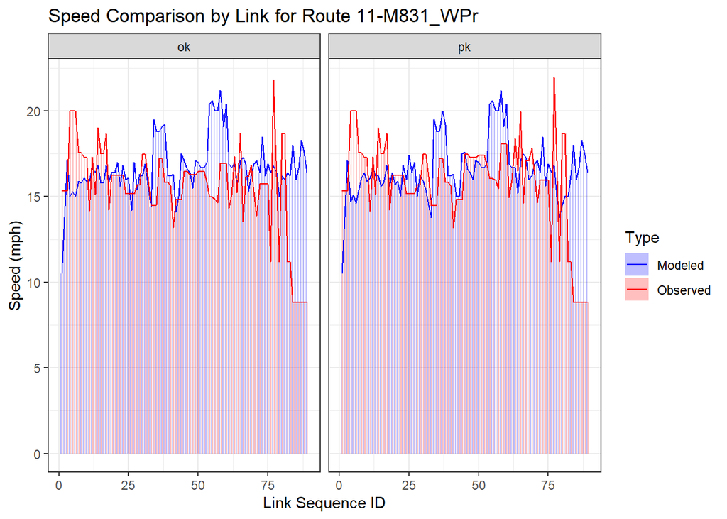

```r
histo <- tar_read(gtfs_histo_df)
routeplots <- tar_read(routeplots)
routeplots[[11]]
```

### Scatter and Descending Plot Results

Now we create plots comparing the TDM speed with GTFS speed values by functional classification groupings (as shown in the ratio table) and mode. An example is shown below as well.

```r
join_gtfs_speeds <- tar_read(joint_gtfs_speeds)
mutated_gtfs <- tar_read(mutated_gtfs_speeds)
```

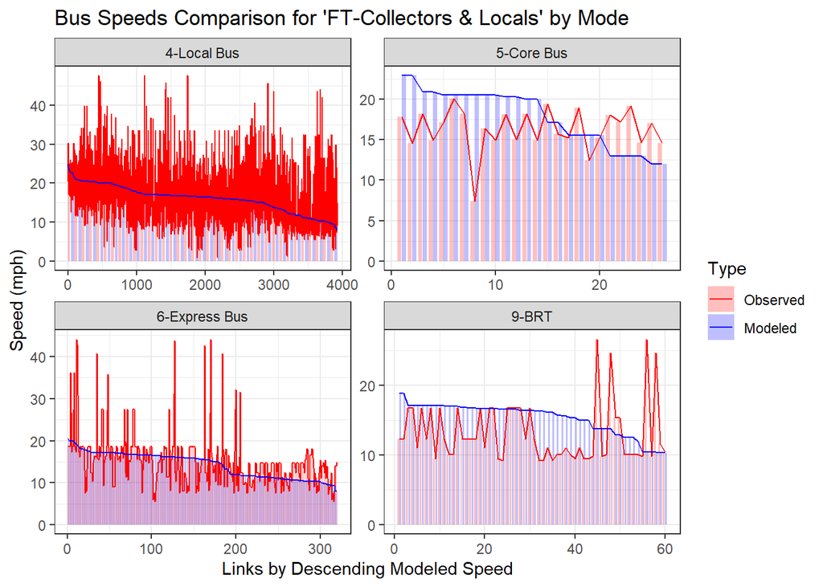

```r
g_descLineGraphs <- tar_read(g_descLineGraphs)
g_descScatterPlots <- tar_read(g_descScatterPlots)
g_aveScatterPlots <- tar_read(g_aveScatterPlots)
g_errScatterPlots <- tar_read(g_errScatterPlots)

#makePNGs(g_descLineGraphs, "outputs/GTFS/DescendingSpeeds_Exact")
#makePNGs(g_descScatterPlots, "outputs/GTFS/DescendingSpeeds_Average")
#makePNGs(g_aveScatterPlots, "outputs/GTFS/ScatterPlotSpeeds_Average")
#makePNGs(g_errScatterPlots, "outputs/GTFS/ScatterPlotSpeeds_Error")

g_descLineGraphs[[1]]
```